# CIFAR-10 Classification project FCN

```python
import keras
from tensorflow.keras.models import Sequential
from tensorflow.keras.layers import Input, Dense, Flatten, Dropout, BatchNormalization
from tensorflow.keras.utils import to_categorical
import matplotlib.pyplot as plt
```

### Data preparation

Load data and reshape it to be in the approriate form. Also scale the values to 0.0-1.0 for better performance

```python
# Load data
(x_train, y_train), (x_test, y_test) = keras.datasets.cifar10.load_data()
```

```python
print(x_train.shape, y_train.shape)
print(x_test.shape, y_test.shape)
```

```
(50000, 32, 32, 3) (50000, 1)
(10000, 32, 32, 3) (10000, 1)
```

```python
# Reshape and scale to 0.0-1.0
x_train = x_train.reshape(50000, 32*32*3).astype("float32") /255
x_test = x_test.reshape(10000, 32*32*3).astype("float32") /255
```

### Model

```python
# Build layers
model = Sequential([
    Input(shape=(3072,)),
    Dense(1024, activation='relu'),
    BatchNormalization(),
    Dense(512, activation='relu'),
    BatchNormalization(),
    Dense(256, activation='relu'),
    BatchNormalization(),
    Dense(128, activation='relu'),
    Dropout(0.5),
    Dense(10, activation='softmax')
])
```

```python
model.summary()
```

```
Model: "sequential_39"
```

```
┏━━━━━━━━━━━━━━━━━━━━━━━━━━━━━━━━━┳━━━━━━━━━━━━━━━━━━━━━━━━┳━━━━━━━━━━━━━━━┓
┃ Layer (type)                    ┃ Output Shape           ┃       Param # ┃
┡━━━━━━━━━━━━━━━━━━━━━━━━━━━━━━━━━╇━━━━━━━━━━━━━━━━━━━━━━━━╇━━━━━━━━━━━━━━━┩
│ dense_188 (Dense)               │ (None, 1024)           │     3,146,752 │
├─────────────────────────────────┼────────────────────────┼───────────────┤
│ batch_normalization_71          │ (None, 1024)           │         4,096 │
│ (BatchNormalization)            │                        │               │
├─────────────────────────────────┼────────────────────────┼───────────────┤
│ dense_189 (Dense)               │ (None, 512)            │       524,800 │
├─────────────────────────────────┼────────────────────────┼───────────────┤
│ batch_normalization_72          │ (None, 512)            │         2,048 │
│ (BatchNormalization)            │                        │               │
├─────────────────────────────────┼────────────────────────┼───────────────┤
│ dense_190 (Dense)               │ (None, 256)            │       131,328 │
├─────────────────────────────────┼────────────────────────┼───────────────┤
│ batch_normalization_73          │ (None, 256)            │         1,024 │
│ (BatchNormalization)            │                        │               │
├─────────────────────────────────┼────────────────────────┼───────────────┤
│ dense_191 (Dense)               │ (None, 128)            │        32,896 │
├─────────────────────────────────┼────────────────────────┼───────────────┤
│ dropout_43 (Dropout)            │ (None, 128)            │             0 │
├─────────────────────────────────┼────────────────────────┼───────────────┤
│ dense_192 (Dense)               │ (None, 10)             │         1,290 │
└─────────────────────────────────┴────────────────────────┴───────────────┘
```

```
 Total params: 11,525,536 (43.97 MB)
```

```
 Trainable params: 3,840,650 (14.65 MB)
```

```
 Non-trainable params: 3,584 (14.00 KB)
```

```
 Optimizer params: 7,681,302 (29.30 MB)
```

```python
# Model options
model.compile(optimizer='adam',
              loss=keras.losses.SparseCategoricalCrossentropy(),
              metrics=['accuracy'],
)
```

```python
# Training options
history = model.fit(x_train, y_train, epochs=20, batch_size=64, validation_split=0.2)
```

```
625/625 ━━━━━━━━━━━━━━━━━━━━ 10s 9ms/step - accuracy: 0.3176 - loss: 1.9263 - val_accuracy: 0.3668 - val_loss: 1.7434
625/625 ━━━━━━━━━━━━━━━━━━━━ 4s 7ms/step - accuracy: 0.3998 - loss: 1.6930 - val_accuracy: 0.3389 - val_loss: 1.8802
625/625 ━━━━━━━━━━━━━━━━━━━━ 4s 7ms/step - accuracy: 0.4291 - loss: 1.6053 - val_accuracy: 0.3776 - val_loss: 1.7201
625/625 ━━━━━━━━━━━━━━━━━━━━ 4s 7ms/step - accuracy: 0.4487 - loss: 1.5549 - val_accuracy: 0.3982 - val_loss: 1.6881
625/625 ━━━━━━━━━━━━━━━━━━━━ 4s 7ms/step - accuracy: 0.4666 - loss: 1.4994 - val_accuracy: 0.4301 - val_loss: 1.5993
625/625 ━━━━━━━━━━━━━━━━━━━━ 4s 7ms/step - accuracy: 0.4808 - loss: 1.4458 - val_accuracy: 0.4377 - val_loss: 1.5618
625/625 ━━━━━━━━━━━━━━━━━━━━ 4s 7ms/step - accuracy: 0.4944 - loss: 1.4169 - val_accuracy: 0.4437 - val_loss: 1.5772
625/625 ━━━━━━━━━━━━━━━━━━━━ 4s 7ms/step - accuracy: 0.5112 - loss: 1.3767 - val_accuracy: 0.4713 - val_loss: 1.5199
625/625 ━━━━━━━━━━━━━━━━━━━━ 4s 7ms/step - accuracy: 0.5197 - loss: 1.3463 - val_accuracy: 0.4621 - val_loss: 1.5215
625/625 ━━━━━━━━━━━━━━━━━━━━ 4s 7ms/step - accuracy: 0.5377 - loss: 1.2992 - val_accuracy: 0.4866 - val_loss: 1.4788
625/625 ━━━━━━━━━━━━━━━━━━━━ 4s 7ms/step - accuracy: 0.5505 - loss: 1.2702 - val_accuracy: 0.4616 - val_loss: 1.5760
625/625 ━━━━━━━━━━━━━━━━━━━━ 4s 7ms/step - accuracy: 0.5584 - loss: 1.2390 - val_accuracy: 0.4752 - val_loss: 1.5209
625/625 ━━━━━━━━━━━━━━━━━━━━ 4s 6ms/step - accuracy: 0.5668 - loss: 1.2102 - val_accuracy: 0.5062 - val_loss: 1.4173
625/625 ━━━━━━━━━━━━━━━━━━━━ 4s 6ms/step - accuracy: 0.5793 - loss: 1.1831 - val_accuracy: 0.5041 - val_loss: 1.4651
625/625 ━━━━━━━━━━━━━━━━━━━━ 4s 7ms/step - accuracy: 0.5881 - loss: 1.1541 - val_accuracy: 0.4860 - val_loss: 1.5462
625/625 ━━━━━━━━━━━━━━━━━━━━ 4s 7ms/step - accuracy: 0.5931 - loss: 1.1365 - val_accuracy: 0.4907 - val_loss: 1.4949
625/625 ━━━━━━━━━━━━━━━━━━━━ 4s 7ms/step - accuracy: 0.6026 - loss: 1.1137 - val_accuracy: 0.4971 - val_loss: 1.4996
625/625 ━━━━━━━━━━━━━━━━━━━━ 4s 7ms/step - accuracy: 0.6130 - loss: 1.0873 - val_accuracy: 0.5098 - val_loss: 1.4639
625/625 ━━━━━━━━━━━━━━━━━━━━ 4s 7ms/step - accuracy: 0.6194 - loss: 1.0607 - val_accuracy: 0.5141 - val_loss: 1.4485
625/625 ━━━━━━━━━━━━━━━━━━━━ 4s 6ms/step - accuracy: 0.6295 - loss: 1.0383 - val_accuracy: 0.5119 - val_loss: 1.4447
```

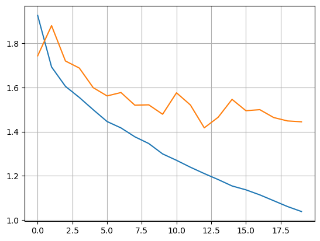

```python
# Plot validation loss compared to loss
plt.plot(history.history["loss"])
plt.plot(history.history["val_loss"])
plt.grid()
plt.show()
```

```python
test_scores = model.evaluate(x_test, y_test, verbose=2)
print("Test loss:", test_scores[0])
print("Test accuracy:", test_scores[1])
```

```
313/313 - 2s - 5ms/step - accuracy: 0.5113 - loss: 1.4286
Test loss: 1.428582787513733
Test accuracy: 0.5113000273704529
```

### Model tuning methodology

Tried different setups for the model. Tried different amounts of layers and cells. Then tried different epochs to find more accurate models without too much overfitting. Started with fewer layers and less cells in the layers, but noticed an increase in accuracy when adding more layers and cells up to the point show above (4 hidden layers with 1028-512-256-128 cells respectively).  
Added batch normalization which increased model accuracy by multiple percentage points, but it also made the validation loss graph more erratic. Dropout also improved performance by a little. Trying with more dropouts made the model more unstable.

### Analysis

From the example prediction results below we see that the confidence of the predictions varies a lot. It seems to give >50% probabilites a small majority of the time for the top guess even if the guess is wrong.  
For example, in picture 7 and 14 below the prediction is quite confidently wrong. In picture 14 it's quite understandable that planes and birds are easier to mix up in a picture where they are in flight, the angle is from above and the planes wings are not standard style airplane wings (I would also assume very few of the plane pictures are of a stealth bomber). In picture 7 There probably aren't many horse pictures where the horse is "upright" and also the model predicted some horse pictures as trucks (also picture 18).  
There were more mixed results of animal picture where the angle/zoom etc. where not "standard" where it distributed the odds to multiple animals.

The comparison analysis between this model and the CNN-model will be in the CNN-models documentation.

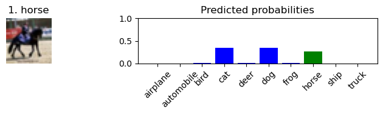

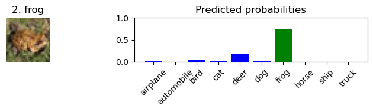

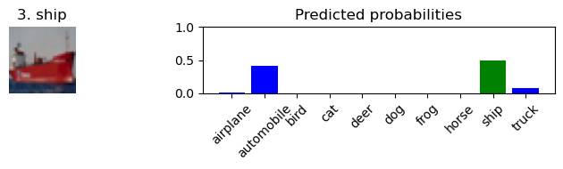

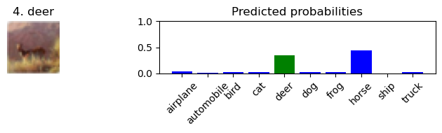

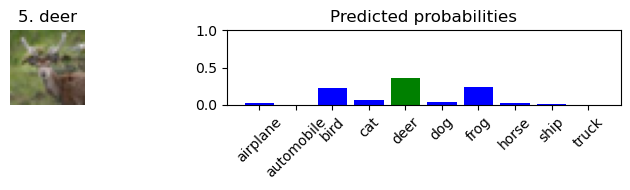

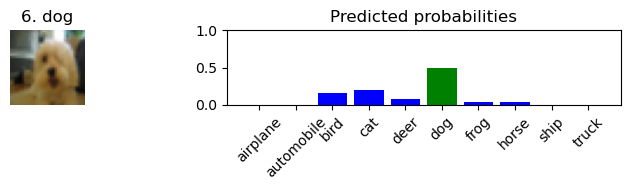

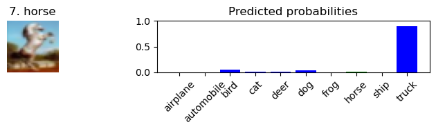

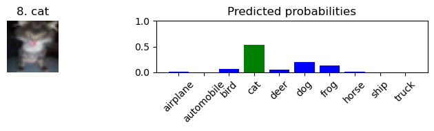

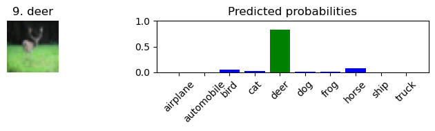

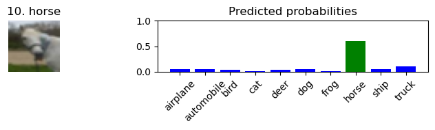

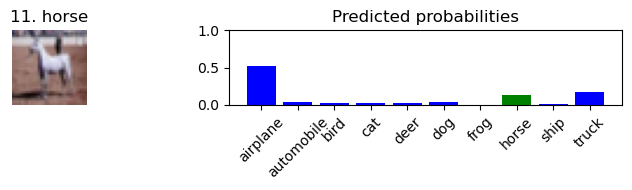

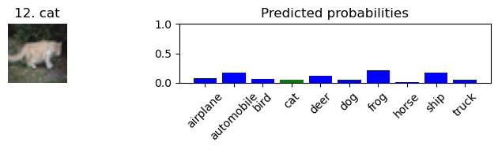

[8 more figures not shown]

```python
import numpy as np
import matplotlib.pyplot as plt

x = x_test
y_pred = model(x)
start = 5000
labels = ["airplane","automobile","bird","cat","deer","dog","frog","horse","ship","truck"]

for k in range(20):
    plt.figure(figsize=(8, 2))

    # Show image
    plt.subplot(1, 2, 1)
    plt.imshow(x[start+k].reshape((32, 32, 3)))
    plt.axis("off")
    true_label_idx = int(y_test[start+k]) if y_test.ndim == 1 else int(y_test[start+k, 0])
    plt.title(f"{k+1}. {labels[true_label_idx]}")

    # Show bar graph
    plt.subplot(1, 2, 2)
    probs = y_pred[start+k].numpy().flatten()

    # Color the correct label green
    colors = ["green" if i == true_label_idx else "blue" for i in range(10)]
    plt.bar(range(10), probs, color=colors)
    plt.xticks(range(10), labels, rotation=45)
    plt.ylim([0, 1])
    plt.title("Predicted probabilities")

    plt.tight_layout()
    plt.show()
```

```python
# Save model
model.save('./CIFAR_10_FCN.keras')
```